# STAT412 HOMEWORK_1

Denizcan Taşdelen (2361509)

10 04 2023

```r
library(dplyr)
library(ggplot2)
library(ggforce)
library(statsExpressions)
library(ggalt)
library(bbplot)
library(leaflet)
library(readxl)
library(tidyverse)
library(stringr)
library(dplyr)
```

**QUESTION 1**

**q1) which are the top 10 country having the highest number of power plants?**

```r
#Importing base dataset
power_data <- read.csv("global_power_plant_database.csv")

#there is no any NA value in the variable "name", so, number of relevant country name equals to the number of power plants in this country.
which(is.na(power_data$name))
```

```
## integer(0)
```

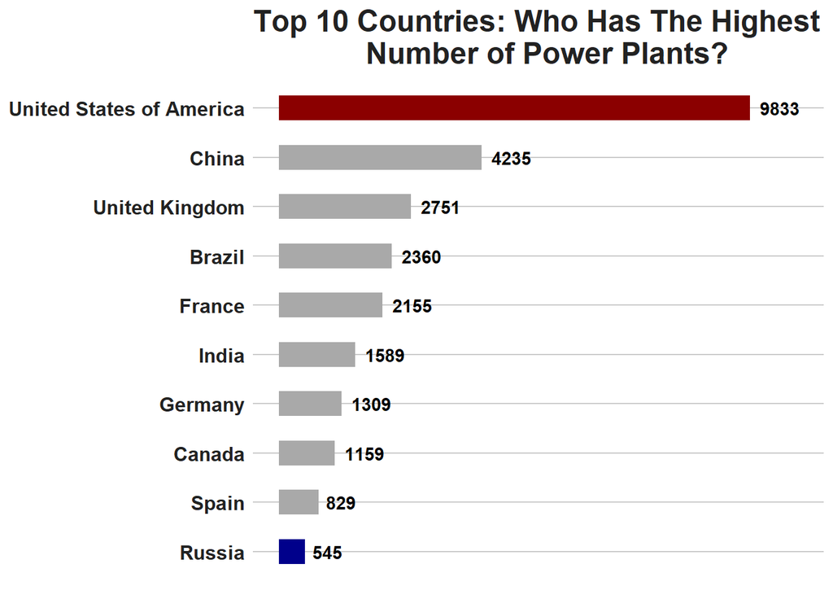

```r
#Calculating total number of power plants and then choosing top 10
q1 <- sort(table(power_data$country_long), decreasing=TRUE)[1:10]
q1 <- data.frame(q1)
colnames(q1) <- c("value", "count")

value <- q1$value
count <- q1$count

#Assigning colors to these top 10 countries: red==>higher, blue==>lower number of power plants
tr <- list()
for (i in 1:length(count)) {
  if(count[i] == max(count)) {
    tr[i] <- "darkred"
  }
  if(count[i] == min(count)) {
    tr[i] <- "darkblue"
  }
  if(count[i] != max(count) & count[i] != min(count)) {
    tr[i] <- "darkgrey"
  }
}

tr <- unlist(tr)

kk <- data.frame(value, count, tr)

#Ordering columns with respect to first latter of country names because ggplot scale_fill_manual orders things according to these first letters.
newdata <- kk[order(value), ]

tr <- newdata$tr

ggplot(kk,aes(x=reorder(value, count), y=count, fill=value))+geom_bar(stat="identity",width=0.5)+ylim(0,max(count)+1000)+
  labs(title="Top 10 Countries: Who Has The Highest
              Number of Power Plants?",y="count",x="value")+
  scale_fill_manual(values=tr)+
  geom_text(aes(label=count),hjust=-0.25,fontface="bold")+bbc_style()+coord_flip()+
  theme(plot.title = element_text(size=18),axis.text = element_text(size=12,face="bold"),
        legend.text = element_text(size=10),axis.text.x = element_blank(),legend.position='none')
```

It is clear that USA has the highest number of power plants, and Russia has the lowest number, among 10 countries.

**q2) What are the locations and the magnitude of power plants in Türkiye?**

```r
#Filtering data belonging to Türkiye
power_data_türkiye <- power_data[power_data$country_long=="Turkey", ]

#min of capacity_mw is 3.7 and max is 2795.0
summary(power_data_türkiye$capacity_mw)
```

```
##    Min. 1st Qu.  Median    Mean 3rd Qu.    Max.
##     3.7     9.0    45.0   315.6   493.0  2795.0
```

```r
#I created breakes randomly for the range 3.7 and 2795.0
power_data_türkiye$magrange <- cut(power_data_türkiye$capacity_mw,
                                      breaks=c(3.7, 1000, 1600, 2795),
                                      right=FALSE,
                                      labels=c("Light", "Moderate", "Strong")
                                      )

pal <- colorFactor(palette=c("blue", "yellow", "red"), domain=power_data_türkiye$magrange)

leaflet(power_data_türkiye) %>% addTiles() %>%
  addCircles(lng = ~power_data_türkiye$longitude, lat = ~power_data_türkiye$latitude, color=~pal(magrange),
             radius=10000,
             label=paste("Magnitude:", power_data_türkiye$capacity_mw, "type:", power_data_türkiye$magrange))
```

[interactive chart not shown]

**q3) What is the distribution of amount of energy (gwh) generated in 2016 by European Union Countries?**

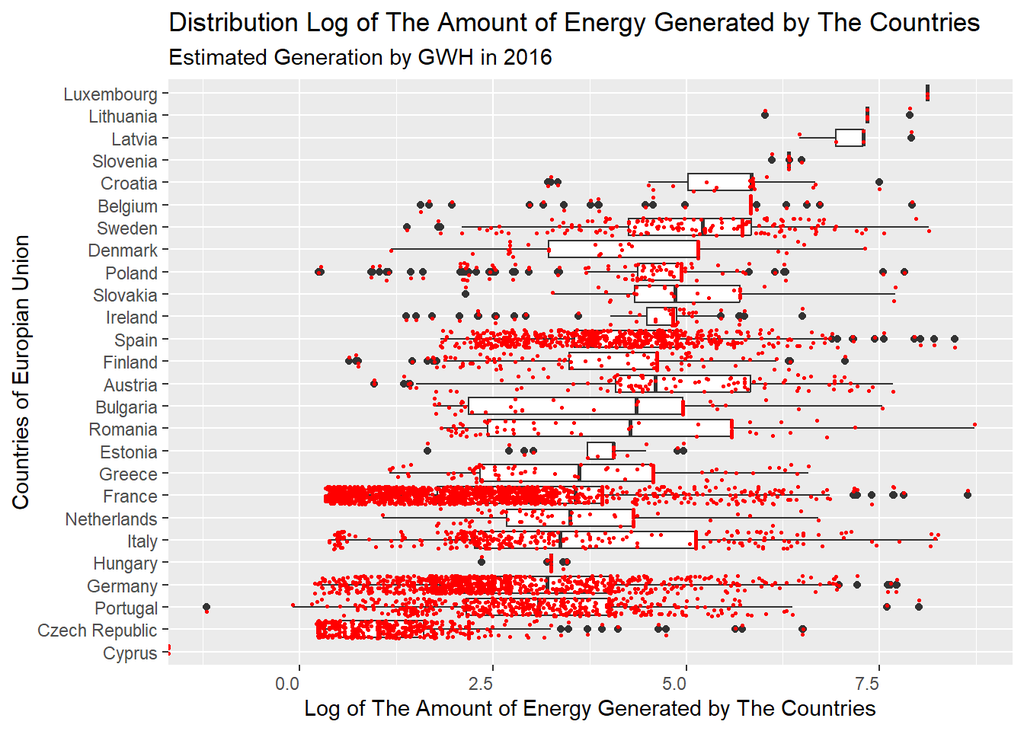

```r
#Countries in European Union (from wikipedia)
countries_in_EU <- c("Austria", "Belgium", "Bulgaria", "Croatia", "Cyprus", "Czech Republic", "Denmark", "Estonia", "Finland",
                     "France", "Germany", "Greece", "Hungary", "Ireland", "Italy", "Latvia", "Lithuania", "Luxembourg", "Malta",
                     "Netherlands", "Poland", "Portugal", "Romania", "Slovakia", "Slovenia", "Spain", "Sweden")

#Selecting coutries in EU from  our base dataset
data_in_EU <- power_data[power_data$country_long %in% countries_in_EU, ]

#NA values in the "estimated_generation_gwh_2016" column of data_in_EU has been changed with mean value of estimated_generation_gwh_2016 of their appropriate countries.
for (i in levels(as.factor(data_in_EU$country_long))) {
  data_in_EU$estimated_generation_gwh_2016[which(data_in_EU$country_long==i)[which(data_in_EU$country_long==i) %in% which(is.na(data_in_EU$estimated_generation_gwh_2016))==TRUE]] <- mean(data_in_EU$estimated_generation_gwh_2016[which(data_in_EU$country_long==i)[(which(data_in_EU$country_long==i) %in% which(is.na(data_in_EU$estimated_generation_gwh_2016))==FALSE)]])
}

#Some countries do not have any value for estimated_generation_gwh_2016. So, their mean is calculated as NaN. NaN vales have been replaced with zeros.
data_in_EU$estimated_generation_gwh_2016[which(is.na(data_in_EU$estimated_generation_gwh_2016))] <- 0

#For better comparison, log of the numbers are taken
data_in_EU  %>%
  ggplot(aes(x = forcats::fct_reorder(country_long, log(estimated_generation_gwh_2016)), y = log(estimated_generation_gwh_2016))) +
  geom_boxplot() +
  geom_jitter(col = "red", size = 0.5) +
  coord_flip() +
  theme(axis.text.x = element_text(angle = 0, , hjust = 1)) +
  labs(title = "Distribution Log of The Amount of Energy Generated by The Countries",
       subtitle = "Estimated Generation by GWH in 2016",
       x = "Countries of Europian Union",
       y = "Log of The Amount of Energy Generated by The Countries")
```

**q4) How Hydro Energy production changed among countries Japan, Portugal, Poland, United States of America, Russia and Spain between 2013 and 2017?**

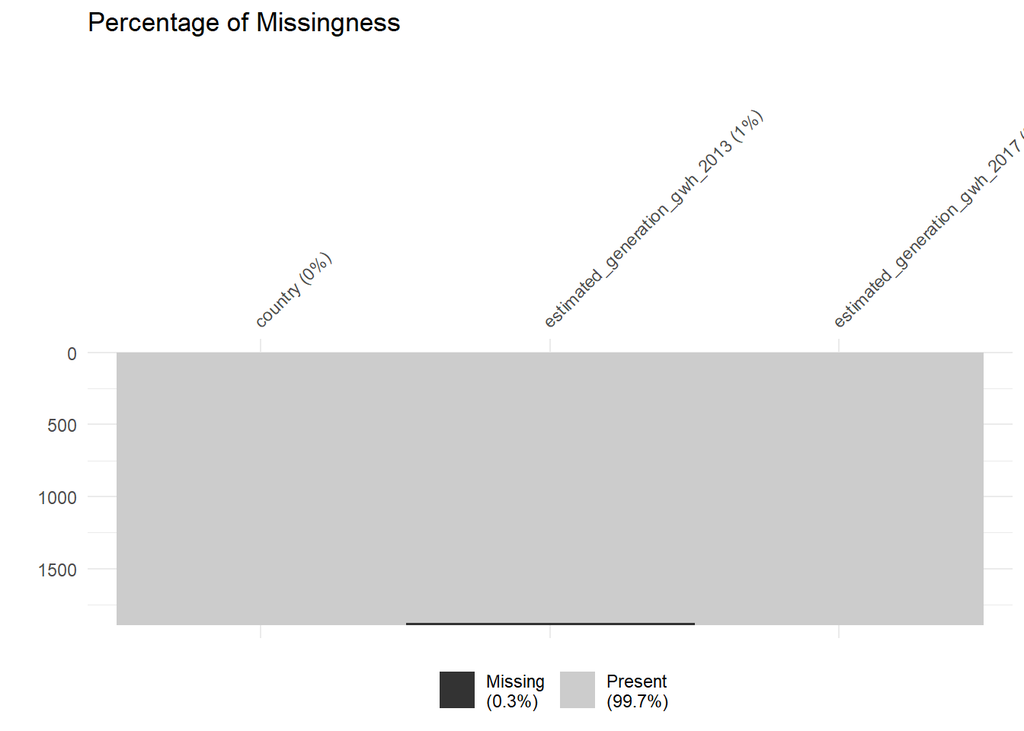

```r
#assigning related countries
q3_countries <- c("Japan", "Portugal", "Poland", "United States of America", "Russia", "Spain")

#choosing appropriate data from base dataset
q3_data <- power_data[power_data$country_long %in% q3_countries, ]

#selecting primary_fuel as only "Hydro"
q3_data <- q3_data[q3_data$primary_fuel=="Hydro", ]

#Selecting appropriate columns: just country names and estimated_generation_gwh of these countries in 2013 and 2017
q3_data <- data.frame(q3_data$country_long, q3_data$estimated_generation_gwh_2013, q3_data$estimated_generation_gwh_2017)

colnames(q3_data) <- c("country", "estimated_generation_gwh_2013", "estimated_generation_gwh_2017")

#There are only a few NAs in one variable, so, I removed them.
library(naniar)
vis_miss(q3_data, cluster=TRUE)+labs(title = "Percentage of Missingness",
                                     subtitle = "", x = "", y = "")
```

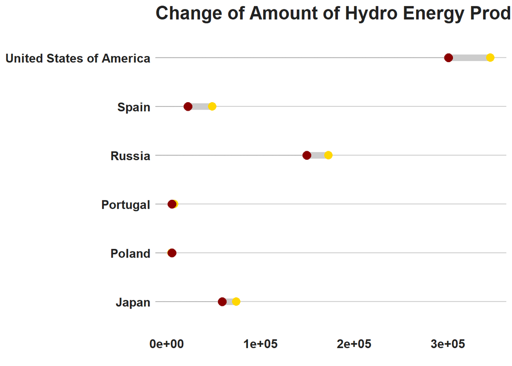

```r
#calculating total energy production in 2013 and 2017 by country wise
q3_data_1 <- q3_data %>% group_by(country) %>% summarize(sum(estimated_generation_gwh_2013, na.rm=TRUE))
q3_data_2 <- q3_data %>% group_by(country) %>% summarize(sum(estimated_generation_gwh_2017, na.rm=TRUE))

#Below codes are for some arrangements
q3_data_1 <- as.data.frame(q3_data_1)
q3_data_2 <- as.data.frame(q3_data_2)

q3_data <- cbind(q3_data_1, q3_data_2)

colnames(q3_data) <- c("cont1", "2013", "cont2", "2017")

q3_data <- q3_data[, c("cont1", "2013", "2017")]

colnames(q3_data) <- c("country", "estimated_generation_gwh_2013", "estimated_generation_gwh_2017")

ggplot(q3_data, aes(y=country, x=estimated_generation_gwh_2013, xend=estimated_generation_gwh_2017)) +
  geom_dumbbell(size=3, color="gray80",
                colour_x = "gold1", colour_xend = "darkred",
                dot_guide=TRUE, dot_guide_size=0.1) +
  labs(title="Change of Amount of Hydro Energy Production Generated Between 2013 and 2017",y="country",x="Level")+
  scale_fill_manual(values=c("darkred","gold1","maroon","steelblue","darkblue", "darkblue"))+bbc_style() +
  theme(plot.title = element_text(size=18),plot.subtitle = element_text(size=10),axis.text = element_text(size=12,face="bold"),legend.text = element_text(size=9),legend.position='top',
        legend.justification='left',
        legend.direction='horizontal')
```

Here, while yellow dots represent total production in 2013, red ones for 2017. As we see, hydro energy production of most of these countries decreased in four years, moving from yellow to red.

**q5) How Turkey’s total energy production capacity change by fuel type used?**

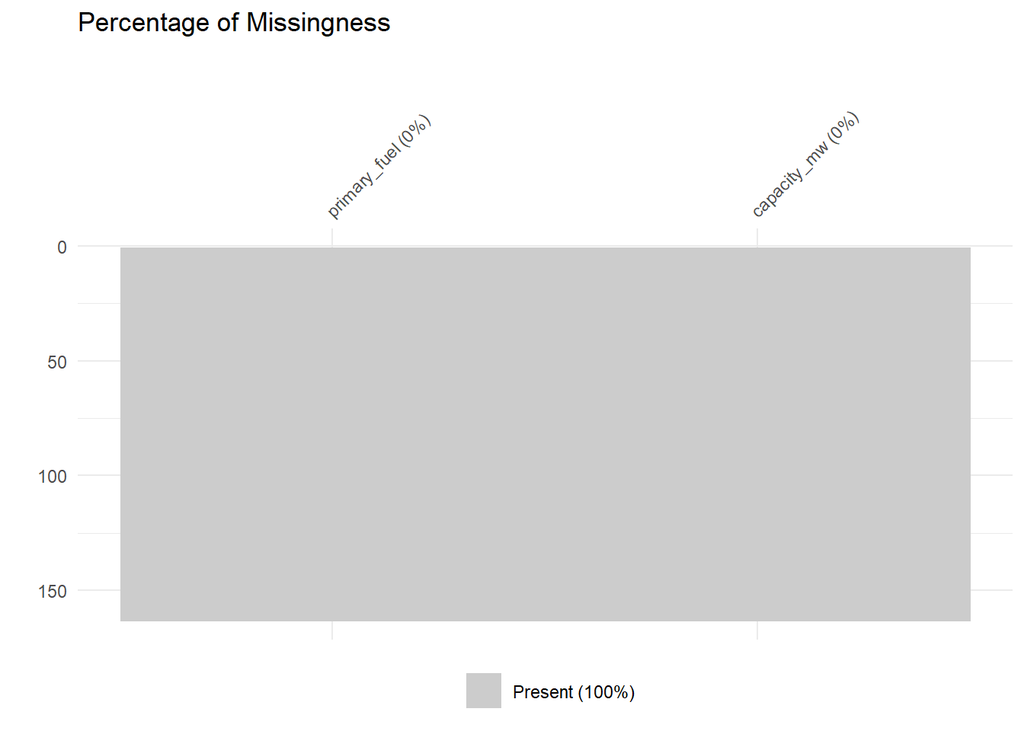

```r
#Extracting information only about Türkiye from base dataset
türkiye_data <- power_data[power_data$country_long=="Turkey", ]

#Selecting variables of interest
türkiye_data <- türkiye_data[, c("primary_fuel", "capacity_mw")]

#Visualization of percentage of missingness in the data
vis_miss(türkiye_data)+labs(title = "Percentage of Missingness",
       subtitle = "", x = "", y = "")
```

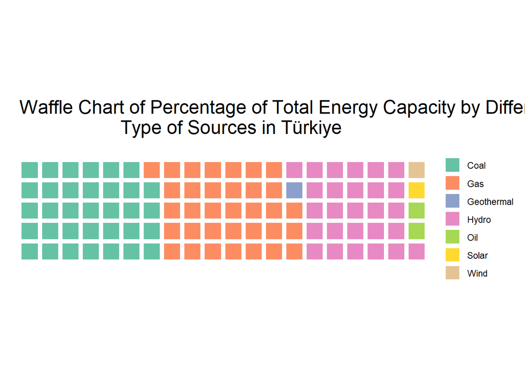

```r
#Calculating the percentage that each fuel type represents in the total energy capacity
obs_by_primary_fuel <- türkiye_data %>% group_by(primary_fuel) %>% summarise(sum_obs=sum(capacity_mw)) %>% mutate(percent=round(sum_obs/sum(sum_obs)*100))

#Extracting percentages
percent_by_fuel <- obs_by_primary_fuel$percent

#Gives names to these extracted percentages
names(percent_by_fuel) <- obs_by_primary_fuel$primary_fuel

#Waffle Chart
waffle::waffle(percent_by_fuel, rows=5) +
  labs(title = "Waffle Chart of Percentage of Total Energy Capacity by Different
                    Type of Sources in Türkiye",
       subtitle = "", x = "", y = "")
```

According to above waffle chart, most of the power of Türkiye is generated using coal and gas. Geotermal, solar and wind power are the energy sources least used in Türkiye.

**q6) Is there a difference between parts of the African Continent and China that power plants accumulate?**

```r
#Countries in the African continent
african_countries <- c("Algeria", "Angola", "Benin", "Cameroon", "Central", "African Republic", "Cape Verde", "Congo",
                       "Cote DIvoire", "Democratic Republic of the Congo", "Djibouti", "Egypt", "Eritrea", "Equatorial Guinea",
                       "Ethiopia", "Gabon", "Gambia", "Ghana", "Kenya", "Lesotho", "Malawi", "Mali", "Mauritania", "Mauritius",
                       "Mozambique", "Namibia", "Nigeria", "Niger", "Rwanda", "Senegal", "South Africa", "Togo", "Uganda",
                       "Western Sahara", "Zambia", "Zimbabwe")

africa_data <- power_data[power_data$country_long %in% african_countries, ]

power_data_usa <- power_data[power_data$country_long=="China", ]

data <- rbind(africa_data, power_data_usa)

data$col <- ifelse(data$country_long=="China", "China", "African Country")

pal <- colorFactor(palette=c("blue","red"), domain=data$col)

leaflet(data) %>% addTiles() %>%
  addCircles(lng = ~data$longitude, lat = ~data$latitude, color=~pal(col),
             radius=5000)
```

[interactive chart not shown]

Above map shows that energy plants in Africa mostly accumulated in the coastal areas whereas power plants in China are accumulated more homogeneous through the country.

**QUESTION 2**

```r
#read data
data_4 <- read_excel("data4.xlsx")

#corrects 2. row
data_4$Category[2] <- "Office Supplies _ Furniture"

#separates elements of columns appropriately
data_4 <- data_4 %>% separate_rows(Category, AMOunt, sep = "_")

data_4 <- data.frame(data_4)

#trim both sides of columns Category and AMOunt
data_4$Category <- str_trim(data_4$Category,side="both")
data_4$AMOunt <- str_trim(data_4$AMOunt,side="both")

#correct column names
colnames(data_4) <- str_to_sentence(colnames(data_4))

#correct names of elements of Category column
data_4$Category <- str_to_sentence(data_4$Category)

#there is an inappropriate name "Techhnology"
table(data_4$Category)
```

```
##
##     Accessories             Art         Binders       Fasteners       Furniture
##               1               1               2               1               1
## Office supplies           Paper          Phones          Tables     Techhnology
##               2               1               1               1               1
##      Technology
##               1
```

```r
#corrects it
data_4$Category[which(data_4$Category=="Techhnology")]="Technology"

data_4$Amount <- round(as.numeric(data_4$Amount), 2)

data_4$Amount <- as.numeric(data_4$Amount)

#summation by grouping since there is two "Technology" grouped by "CA-2011-131905"
data_4 <- data_4 %>%
  group_by(Order_id, Category) %>%
  summarise(Amount = sum(Amount))

#corrects first column name
colnames(data_4)[1] <- "Order ID"

data_4 <- data.frame(data_4)

data_4
```

```
##          Order.ID        Category  Amount
## 1  CA-2011-131905 Office supplies    7.20
## 2  CA-2011-131905      Technology   84.05
## 3  CA-2011-167199             Art    5.48
## 4  CA-2011-167199         Binders  609.98
## 5  CA-2011-167199       Fasteners  755.96
## 6  CA-2011-167199           Paper   31.12
## 7  CA-2011-167199          Phones  391.98
## 8  Ca-2011-127614     Accessories  234.45
## 9  Ca-2011-127614         Binders   17.46
## 10 Ca-2011-127614          Tables 1256.22
## 11 Ca-2011-149020       Furniture   51.94
## 12 Ca-2011-149020 Office supplies    2.98
```